# Webscraping - Assignment 2

AttilaSerfozo

2020.12.14

## Introduction

In this project I collected data from the catalog of the most used Hungarian used car website hasznaltauto.hu. During the exercise I collect all the available car brands which is presented in the website’s catalog then I create a function to get all information for one car and another function to generate the link of cars for the selected brand. In the end I finish with a function in which the user needs to type in a brand from the brand list, located in the data folder. As there are thousands of observations in case of some brands, and the running of the query can last long I tried the exercise with Bentley (63 observations), Maserati (138 observations), Alfa-Romeo (854 observations) and Honda (1442 observations) as they took a reasonable amount of time.

## Get list of car brands

The list contains the name of the brands in the format in which they need to be inserted into the get_car_data function. The list can be found in the data folder.

```r
main_page <- 'https://katalogus.hasznaltauto.hu/'
t <- read_html(main_page)
brands <-
  t %>%
  html_nodes('.nemlatszik') %>%
  html_text()

# Cleaning brands
brands <- brands[2]
brands <- gsub(' ', '_', trimws(gsub('\n', ',', trimws(gsub('\t', '', trimws(brands), fixed = T)), fixed = T)), fixed = T)
brands <- strsplit(brands,",")[[1]]
brands <- tolower(brands)
brands <- brands[2:107]

write.csv(brands,paste0(data_out,"data/available_brands.csv"))
```

## Function for getting data of one car

This function collects the name, link and all the important data of a brands’ cars.

```r
my_link <- 'https://katalogus.hasznaltauto.hu/abarth/124_spider_1.4_multiair_t-107786'
get_one_car <- function(my_link) {

  t2 <- read_html(my_link)

  specification_list <- list()

  # Collect name of car
  titles <-
    t2 %>%
    html_nodes('h1') %>%
    html_text()
  # Collect link of car
  link <- my_link

  # Add name and link to the list
  specification_list [['Név']] <- titles
  specification_list [['Link']] <- link

  # Collect car data
  category <- t2 %>%  html_nodes('.w250') %>%  html_text()
  values <- t2 %>% html_nodes('.w250+ td') %>%  html_text()
  # Append them to the list
  if (length(category) == length(values)) {
    for (key_id in 1:length(values)) {
      #print(key_id)
      specification_list[[ category[key_id] ]] <- values[key_id]
    }

  }
  return(specification_list)
}
```

## Function for getting car data of the selected brand

This function generates the links of the selected brands’ cars available in the catalog. After generating the links the function combine them with the get_one_car function and gathers all their important properties.

```r
get_car_data <- function(brand) {
  #brand <- 'bentley'

  # Find last page of the brand car list
  x <- read_html(paste0('https://katalogus.hasznaltauto.hu/',brand))
  last_page <-
    x %>%
    html_nodes('.utolso a') %>%
    html_attr('href')

  if(length(last_page) == 0) { # If there is no jump to last page button ~ try maserati
    if (length(x %>%
        html_nodes('.oldalszamozas .oldalszam') %>%
        html_text()) == 0) {   # If there is only 1 page ~ try bentley
      last_page <- 1
    }else{
    last_page <-
      x %>%
      html_nodes('.oldalszamozas .oldalszam') %>%
      html_text()
    last_page <- as.numeric(tail(last_page, n=1))
    }
  }else{                       # If there is a jump to last page button ~ try honda
    last_page <- as.numeric(gsub("[^0-9]","",last_page ) )
  }

  # Generate pagesand car links
  pages <- paste0('https://katalogus.hasznaltauto.hu/',brand,'/page', 1:last_page)

  car_links <- NULL
  for (i in 1:length(pages)) {

    p <- read_html(pages[i])

    car_links <- c(car_links,
                   p %>%
                     html_nodes('.hasonlit-jelolgeto a') %>%
                     html_attr('href')
    )
  }

  df <- rbindlist(lapply(car_links, get_one_car), fill = T)
  return(df)

}
```

# Test the function to download some data

In case of running the function be aware that some cars have more than one thousand items in the catalog, thus sometimes it requires a lot of time to download their data.

```r
car_data1 <- get_car_data('bentley')
write.csv(car_data1,paste0(data_out,"data/raw/bentley-catalog.csv"))
#
# car_data2 <- get_car_data('maserati')
# write.csv(car_data2,paste0(data_out,"data/raw/maserati-catalog.csv"))
#
# car_data3 <- get_car_data('alfa_romeo')
# write.csv(car_data3,paste0(data_out,"data/raw/alfa_romeo-catalog.csv"))
#
# car_data4 <- get_car_data('honda')
# write.csv(car_data4,paste0(data_out,"data/raw/honda-catalog.csv"))
```

## Data Cleaning and exploration of distribution of variables

In the catalog_hasznaltauto-clean_data.R you can find the process of cleaning the scraped raw data file. Please write the name of the selected brand in the “selected_brand” variable to write out the cleaned data.

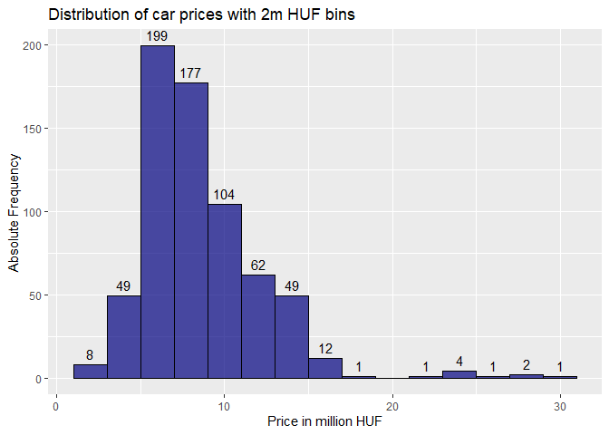

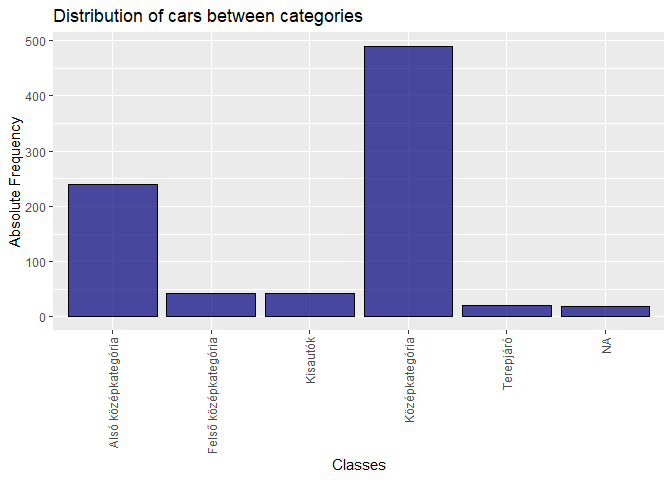

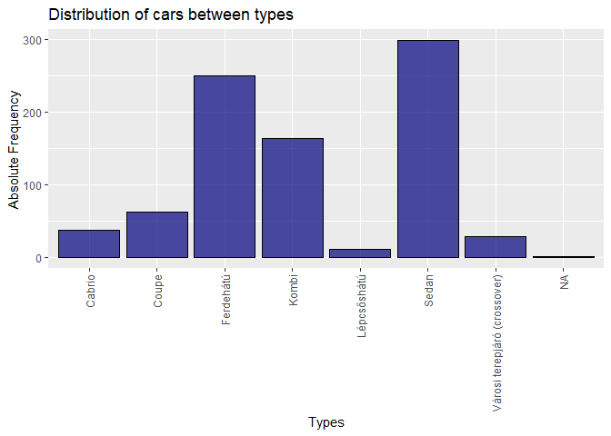

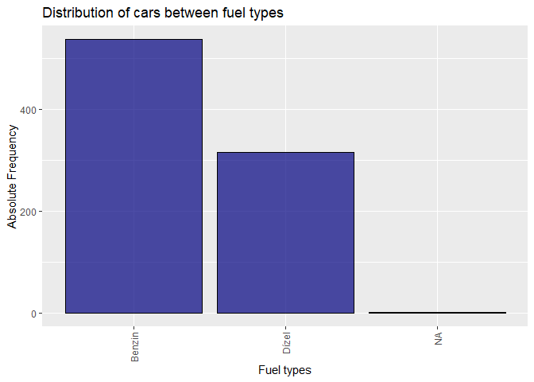

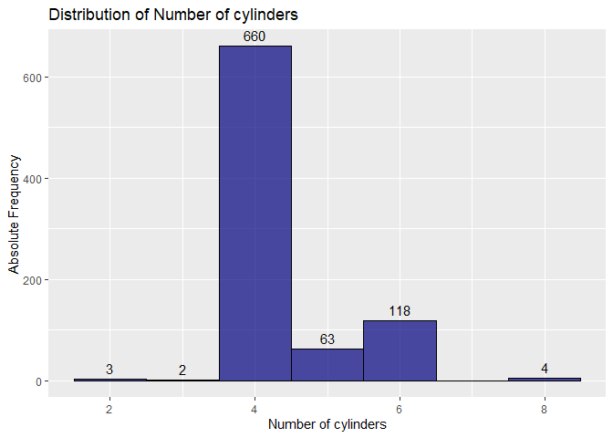

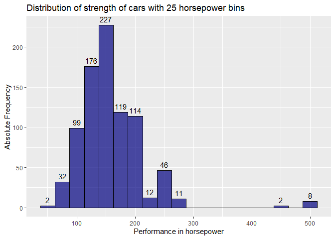

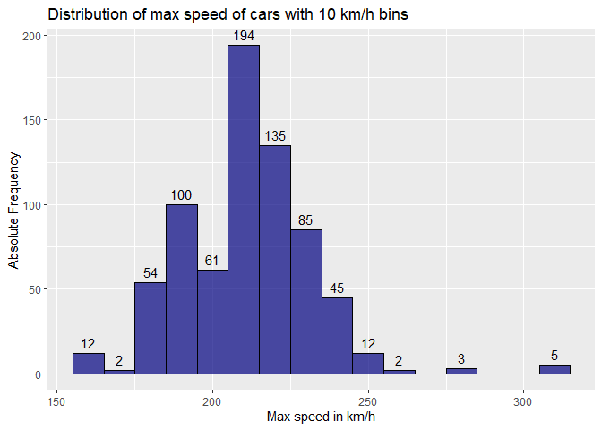

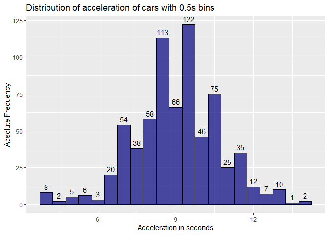

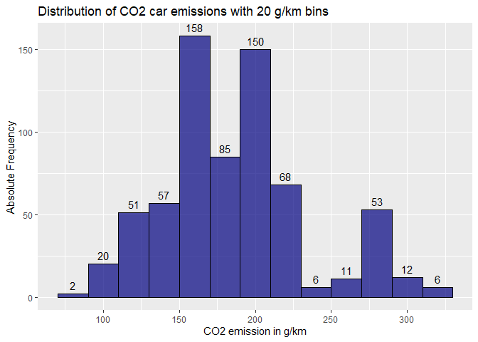

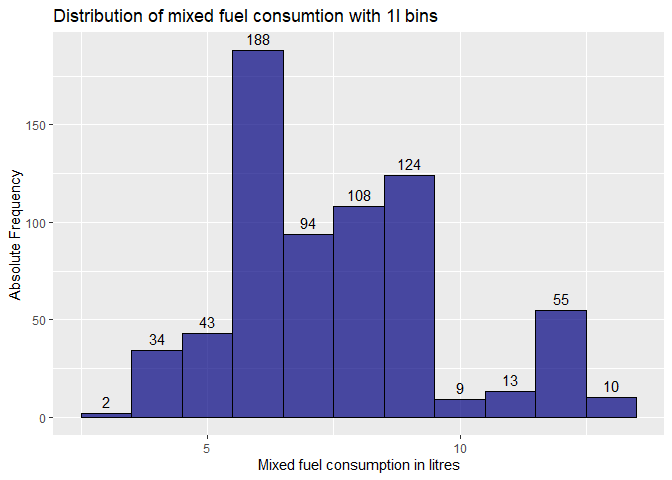

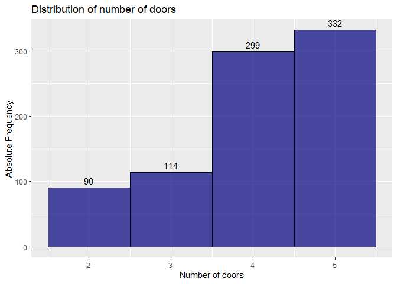

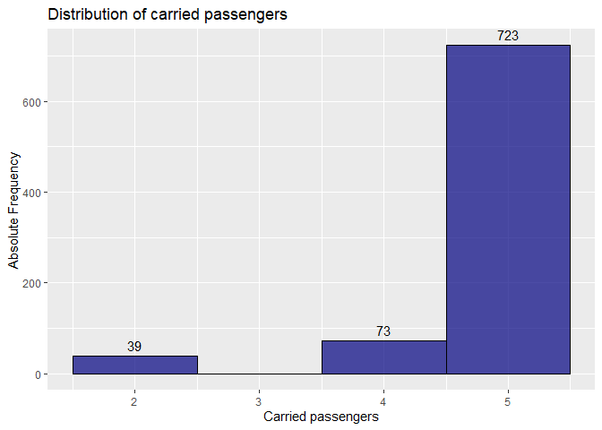

[4 more figures not shown]